# practica2

Paula Jordi

30/12/2020

## 1. Integració i selecció de les dades d’interès a analitzar:

Obtenim les dades del repositori: https://www.kaggle.com/lantanacamara/hong-kong-horse-racing Aquest conté dades dels resultats de les 1561 curses de cavalls fetes a Hong Kong entre el 14 de Setembre del 2014 i el 16 de Juliol de 2017. Aquest està organitzat amb dos fitxers: race-result-horse.csv i race-result-race.csv:

```r
horse.data <- read.csv("./race-result-horse.csv")
race.data <- read.csv("./race-result-race.csv")
```

Unifiquem els dos datasets en un a partir de la variable comú als dos fitxers. Aquesta fa referencia al identificador de la carrera: **race_id**

```r
dataset <- merge(horse.data, race.data, by = "race_id")
attach(dataset) # Per poder fer referencia directament a les variables
dim(dataset)
```

```
## [1] 30189    30
```

## 2. Neteja de les dades:

```r
#head(dataset,5)
str(dataset)
```

```
## 'data.frame':    30189 obs. of  30 variables:
##  $ race_id              : chr  "2014-001" "2014-001" "2014-001" "2014-001" ...
##  $ finishing_position   : chr  "1" "2" "3" "4" ...
##  $ horse_number         : int  1 2 10 3 7 9 13 4 6 11 ...
##  $ horse_name           : chr  "DOUBLE DRAGON" "PLAIN BLUE BANNER" "GOLDWEAVER" "SUPREME PROFIT" ...
##  $ horse_id             : chr  "K019" "S070" "P072" "P230" ...
##  $ jockey               : chr  "B Prebble" "D Whyte" "Y T Cheng" "J Moreira" ...
##  $ trainer              : chr  "D Cruz" "D E Ferraris" "Y S Tsui" "C S Shum" ...
##  $ actual_weight        : chr  "133" "133" "121" "132" ...
##  $ declared_horse_weight: chr  "1032" "1075" "1065" "1222" ...
##  $ draw                 : chr  "1" "13" "3" "2" ...
##  $ length_behind_winner : chr  "-" "2" "2" "2" ...
##  $ running_position_1   : int  1 8 2 6 9 12 4 5 7 11 ...
##  $ running_position_2   : int  2 9 1 4 10 13 3 6 7 11 ...
##  $ running_position_3   : int  2 9 1 5 10 13 3 6 7 12 ...
```

[output cut: 16 more lines]

```r
colnames(dataset)
```

```
##  [1] "race_id"               "finishing_position"    "horse_number"
##  [4] "horse_name"            "horse_id"              "jockey"
##  [7] "trainer"               "actual_weight"         "declared_horse_weight"
## [10] "draw"                  "length_behind_winner"  "running_position_1"
## [13] "running_position_2"    "running_position_3"    "running_position_4"
## [16] "finish_time"           "win_odds"              "running_position_5"
## [19] "running_position_6"    "src"                   "race_date"
## [22] "race_course"           "race_number"           "race_class"
## [25] "race_distance"         "track_condition"       "race_name"
## [28] "track"                 "sectional_time"        "incident_report"
```

Com podem veure, tenim 30 variables amb 30189 observacions. Com que hi ha moltes variables que estan repetides o que no aporten una informació vàlida, n’eliminarem algunes:

1. **incident_report**: Són comentaris sobre la cursa, no utilitzarem aquesta variable per als nostres anàlisis, per tant els podem eliminar.
2. **running_position_X**: Entenem que són les posicions intermitjes de la carrera. No ens aporta informació sobre abans de la carrera, sinó durant aquesta.
3. **SRC**: Tampoc ens aporta res més que el nom dels fitxers de dades.
4. **horse_number**: Depèn de cada cursa i no identifica el cavall, per tant deixem només el **horse_name**.
5. **race_number**: També és reduntant amb les altres variables.
6. **race_date**: La data de la carrera és indiferent per l’anàlisi de les dades.
7. **sectional_time**: Tindrem en compte només el temps total de la carrera, no de cada volta.
8. **horse_id** : Ja tenim un identificador pel cavall, aques és redundant.
9. **length_behind_winner** : És redundant, ja tenim la posició final de la cursa.

```r
eliminar <- c("running_position_1","running_position_2","running_position_3","running_position_4","running_position_5","running_position_6","incident_report","src","race_date","race_number","horse_number","horse_id","sectional_time","length_behind_winner")
dataset_clean <- dataset[ , !(names(dataset) %in% eliminar)]
dataset_clean[] <- lapply(dataset_clean, as.character)
```

### 2.1. Les dades contenen zeros o elements buits? Com gestionaries aquests casos?

Fent una ullada al dataset, veiem que alguns valors NA estan representats com a “—”, “N”, “SH” o “HD”. Canviarem aquests valors a NA per a poder treballar amb la mateixa notació. A més a més, a la columna de **length_behind_winner** (la distància del cavall en qüestió en relació al primer), ens trobem valors representats com a “-”. Aquests corresponen al guanyador de la cursa, el quel no té distància sobre sí mateix, és a dir no són valors buits sinó que representen distància 0. Modificarem la notació per “0”. A la variable **finishing_position**, tenim diversos valors no numèrics, aquests estan representats amb diferents lletres. Per a utilitzar la mateixa notació, canviarem la variable a numèrica i aquells valors no numèrics passaran a estar representats amb “NA”.

```r
dataset_clean[dataset_clean == "-"] <- "0"
dataset_clean[dataset_clean == "---"] <- NA
dataset_clean[dataset_clean == "N"] <- NA
dataset_clean[dataset_clean == "SH"] <- NA
dataset_clean[dataset_clean == "HD"] <- NA
dataset_clean$finishing_position  <- lapply(dataset_clean$finishing_position, as.character)
dataset_clean$finishing_position <- unlist(lapply(dataset_clean$finishing_position, as.integer)) # tots aquells valors que no s'hagin pogut transformar són els no numèrics, i restaran com a "NA".
```

Un cop ja tenim tots els valors buits amb la mateixa identificació, podem mirar si tenim gaires elements buits, i en quines variables.

```r
#paste("Nombre de valors nulls:", sum(is.na(race_id)))
colSums(is.na(dataset_clean))
```

```
##               race_id    finishing_position            horse_name
##                     0                   825                     0
##                jockey               trainer         actual_weight
##                    29                     0                     0
## declared_horse_weight                  draw           finish_time
##                     0                   591                   669
##              win_odds           race_course            race_class
##                   591                     0                     0
##         race_distance       track_condition             race_name
##                     0                     0                     0
##                 track
##                     0
```

Podem observar que tenim alguns valors buits al nostre dataset. Primer ens centrarem en la variable **finishing_position**. Determinem quin % de valors buits representa, per a poder decidir com actuem:

```r
paste("Proporció de valors nulls de la variable finishing_position:", format((sum(is.na(dataset_clean$finishing_position))/nrow(dataset_clean))*100, format = "f", digits = 3), "%")
```

```
## [1] "Proporció de valors nulls de la variable finishing_position: 2.73 %"
```

Veiem que representa un valor molt baix de totes les nostres dades, així que aquest cas el podem gestionar eliminant les observacions nules. Si representés una proporció més gran de les nostres dades, al voltant de 15-20% hauriem d’imputar els missing values, utilitzant un anàlisi de regressió. Observem quans valors nuls tenim ara:

```r
dataset_clean <- dataset_clean[!(is.na(dataset_clean$finishing_position)),] # eliminem les files sense resultats.
colSums(is.na(dataset_clean))
```

```
##               race_id    finishing_position            horse_name
##                     0                     0                     0
##                jockey               trainer         actual_weight
##                     0                     0                     0
## declared_horse_weight                  draw           finish_time
##                     0                     0                     0
##              win_odds           race_course            race_class
##                     0                     0                     0
##         race_distance       track_condition             race_name
##                     0                     0                     0
##                 track
##                     0
```

Un op netejada la variable, ja no tenim més valors buits en les altres columnes. Tot i així, si mirem al dataset original, veiem que hi havia bastants valors buits. Aquests, estaven concentrats en les columnes que hem eliminat perque no ens aportaven informació útil.

```r
#summary(dataset[,-30])
colSums(is.na(dataset[,eliminar]))
```

```
##   running_position_1   running_position_2   running_position_3
##                  615                  629                  647
##   running_position_4   running_position_5   running_position_6
##                13571                26425                29640
##      incident_report                  src            race_date
##                    0                    0                    0
##          race_number         horse_number             horse_id
##                    0                  338                    0
##       sectional_time length_behind_winner
##                    0                    0
```

### 2.2. Identificació i tractament de valors extrems

Per a visualitzar els valors extrems, primer escollirem aquelles variables en les quals podem trobar-nos valors extrems. De totes les variables del nostre dataset, només les variables continues poden tenir valors extrems, aquelles que categòriques o identificatives no en tindran ( **race_id**, **horse_name**, **jockey**, **trainer**, **draw**, **race_course**, **race_name**, **race_class**, **track**, **track_condition**, **finishing_position**, **length_behind_winner**,**race_distance** ). Primer transformem les variables continues a numèriques per poder trobar-ne els outliers.

```r
dataset_clean$actual_weight <- unlist(lapply(dataset_clean$actual_weight, as.integer))
dataset_clean$declared_horse_weight <- unlist(lapply(dataset_clean$declared_horse_weight, as.integer))
dataset_clean$finish_time <-  period_to_seconds(ms(dataset_clean$finish_time))
dataset_clean$win_odds <- unlist(lapply(dataset_clean$win_odds, as.numeric))
dataset_clean$race_distance <- unlist(lapply(dataset_clean$race_distance, as.integer))
```

> **Visualitzem els outliers:** En el nostre dataset, hi tenim diverses curses de cavalls, aquestes tenen diferents distàncies de 1000m a 2400m. Hem de determinar els outliers tenint en compte la distància de la cursa, sinó aquest factor crearà un bias en els costres resultats.

Utilitzem una representació gràfica (histograma i boxplot), per a visualitzar i detectar els outliers:

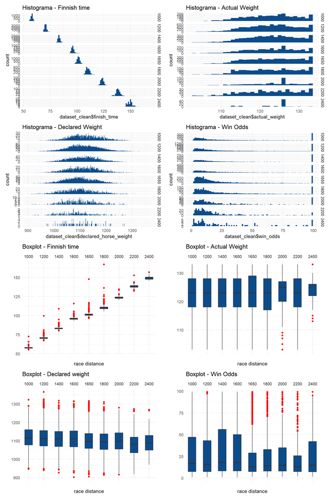

```r
hist_f <- ggplot(data = dataset_clean, aes(x=dataset_clean$finish_time)) +
  facet_grid(rows = vars(dataset_clean$race_distance), scale = "free_y") +
  geom_histogram(binwidth=1, fill="#0c4c8a") +
  theme_minimal() +
  ggtitle("Histograma - Finnish time")

hist_aw <- ggplot(data = dataset_clean, aes(x=dataset_clean$actual_weight)) +
  facet_grid(rows = vars(dataset_clean$race_distance), scale = "free_y") +
  geom_histogram(binwidth=1, fill="#0c4c8a") +
  theme_minimal() +
  ggtitle("Histograma - Actual Weight")

hist_dw <- ggplot(data = dataset_clean, aes(x=dataset_clean$declared_horse_weight)) +
  facet_grid(rows = vars(dataset_clean$race_distance), scale = "free_y") +
  geom_histogram(binwidth=1, fill="#0c4c8a") +
  theme_minimal() +
  ggtitle("Histograma - Declared Weight")

hist_wo <- ggplot(data = dataset_clean, aes(x=dataset_clean$win_odds)) +
  facet_grid(rows = vars(dataset_clean$race_distance), scale = "free_y") +
  geom_histogram(binwidth=1, fill="#0c4c8a") +
  theme_minimal() +
  ggtitle("Histograma - Win Odds")

box_f <- ggplot(dataset_clean) +
  aes(x = "", y = dataset_clean$finish_time) +
  facet_grid(cols = vars(dataset_clean$race_distance), scale = "free") +
  geom_boxplot(fill = "#0c4c8a", outlier.colour = "red") +
  ggtitle("Boxplot - Finnish time") +
  ylab("") + xlab("race distance") +
  theme_minimal()

box_aw <- ggplot(dataset_clean) +
  aes(x = "", y = dataset_clean$actual_weight) +
  facet_grid(cols = vars(dataset_clean$race_distance), scale = "free") +
  geom_boxplot(fill = "#0c4c8a",outlier.colour = "red") +
  ggtitle("Boxplot - Actual Weight") +
  ylab("") + xlab("race distance") +
  theme_minimal()

box_dw <- ggplot(dataset_clean) +
  aes(x = "", y = dataset_clean$declared_horse_weight) +
  facet_grid(cols = vars(dataset_clean$race_distance), scale = "free") +
  geom_boxplot(fill = "#0c4c8a",outlier.colour = "red") +
  ggtitle("Boxplot - Declared weight") +
  ylab("") + xlab("race distance") +
  theme_minimal()

box_wo <- ggplot(dataset_clean) +
  aes(x = "", y = dataset_clean$win_odds) +
  facet_grid(cols = vars(dataset_clean$race_distance), scale = "free") +
  geom_boxplot(fill = "#0c4c8a",outlier.colour = "red") +
  ggtitle("Boxplot - Win Odds") +
  ylab("") + xlab("race distance") +
  theme_minimal()

hist_f + hist_aw + hist_dw + hist_wo + box_f + box_aw + box_dw + box_wo + plot_layout(nrow = 4, ncol = 2)
```

```r
out_aw <- unlist(ggplot_build(box_aw)[["data"]][[1]][["outliers"]])
ind_aw <- which(dataset_clean$actual_weight %in% c(out_aw))
out_f <- unlist(ggplot_build(box_f)[["data"]][[1]][["outliers"]])
ind_f <- which(dataset_clean$finish_time %in% c(out_f))
out_dw <- unlist(ggplot_build(box_dw)[["data"]][[1]][["outliers"]])
ind_dw <- which(dataset_clean$declared_horse_weight %in% c(out_dw))
dataset_outliers <- dataset_clean[-c(ind_f,ind_dw,ind_aw),]
paste("Hem eliminat", (nrow(dataset_clean)-nrow(dataset_outliers)) , "outliers.")
```

```
## [1] "Hem eliminat 6346 outliers."
```

```r
paste("Ara el nostre dataset té", nrow(dataset_outliers), "observacions.")
```

```
## [1] "Ara el nostre dataset té 23018 observacions."
```

```r
dataset_clean <- dataset_outliers
```

## 3. Anàlisi de les dades.

### 3.1. Selecció dels grups de dades que es volen analitzar/comparar (planificació dels anàlisis a aplicar).

### 3.2. 1. Comprovació de la normalitat i homogeneïtat de la variància.

Anem a veure la normalitat i homogeneitat de la variança.

Per a comporvar la normalitat i la homogeneitat, mirarem com estan distribuides les dades, per a comprovar si compleixen amb la hipotesi de la distribució normal de les dades, i si es comporten de manera homogenia. Ho farem de dues maneres: a) De manera visual amb un QQPlot, que ens permetrà tant veure si les dades s’ajusten a la normalitat com veure si és comporten de manera homogènia. b) Amb dos tests. Per comporvar la normalitat usarem el Test de Shapiro–Wilk, el qual és considerat un dels test més potents per a contrastar la normalitat. Per comporvar la homogeneitat, usarem el test de Bartlett, el qual ens permetrà comparar entre els diversos grups alhora.

Les nostres dades estan mesurades amb diferents llargades de curses, aquest fet, altera els valors d’algunes variables (per exemple, el temps d’una cursa de 1000m serà molt diferent al d’una cursa de 2400m) per tant, per a analitzar la shape de les dades caldrà separar-les per llargada. Es a dir, que farem l’estudi per separat de cada tipus de cursa per poder diferenciar bé el comportament.

#### 1. Finish_time

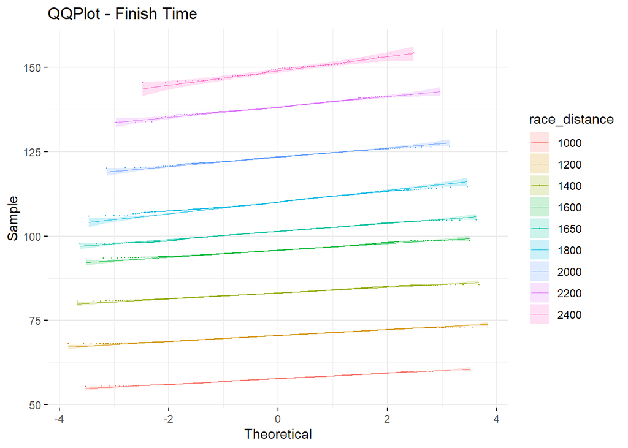

```r
dataset_clean$race_distance <- as.factor(dataset_clean$race_distance)
ggqqplot(data=dataset_clean, x="finish_time", color = "race_distance", ggtheme = theme_minimal(), conf.int = TRUE, size =0.1, title = "QQPlot - Finish Time")
```

```r
SW <- list()
llargada = c(1000,1200,1400,1600,1800,2000,2200,2400)
i = 1
for (ll in llargada) {
  dades <- dataset_clean[dataset_clean$race_distance == ll,9]
  if (length(dades) < 5000) {SW[[i]] <- shapiro.test(dades)}
  else{SW[[i]] <- shapiro.test(dades[1:5000])}
  i = i+1
}

paste("La mitjana del valor W del Test de Shapiro–Wilk:" , mean(c(SW[[1]]$statistic[[1]],SW[[2]]$statistic[[1]],SW[[2]]$statistic[[1]],SW[[2]]$statistic[[1]],SW[[2]]$statistic[[1]],SW[[2]]$statistic[[1]],SW[[2]]$statistic[[1]],SW[[2]]$statistic[[1]])))
```

```
## [1] "La mitjana del valor W del Test de Shapiro–Wilk: 0.997617988793704"
```

```r
paste("El p-value mitjà del Test de Shapiro–Wilk:", mean(c(SW[[1]]$p.value[[1]],SW[[2]]$p.value[[1]],SW[[2]]$p.value[[1]],SW[[2]]$p.value[[1]],SW[[2]]$p.value[[1]],SW[[2]]$p.value[[1]],SW[[2]]$p.value[[1]],SW[[2]]$p.value[[1]])))
```

```
## [1] "El p-value mitjà del Test de Shapiro–Wilk: 2.41382013381222e-06"
```

#### 2. Actual Weight

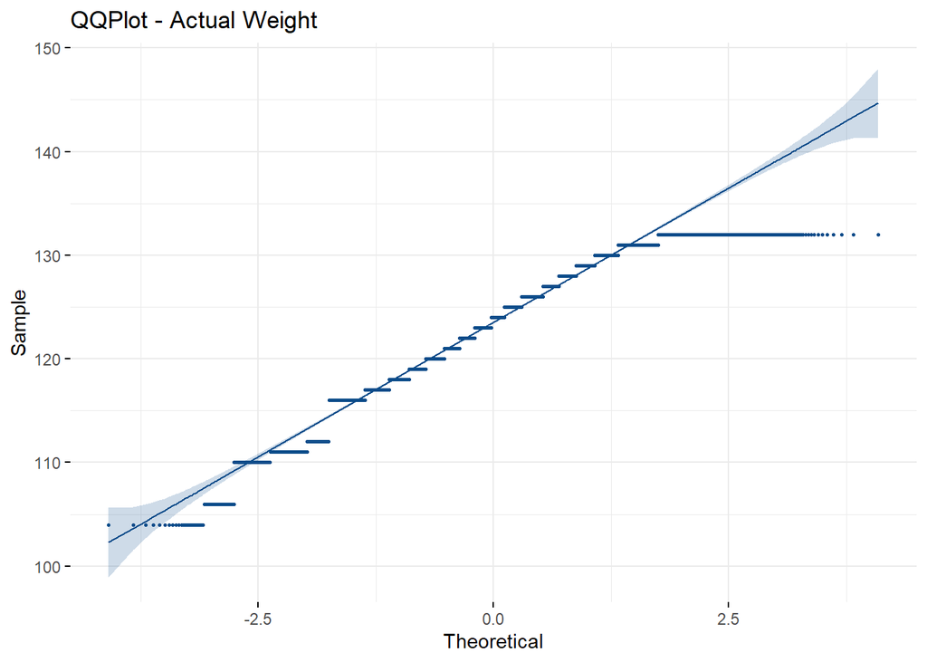

```r
dades <- sample(seq(1,nrow(dataset_clean), by =1), 5000)

ggqqplot(data=dataset_clean, x="actual_weight", ggtheme = theme_minimal(), col = "#0c4c8a", conf.int = TRUE, size = 0.5, title = "QQPlot - Actual Weight")
```

```r
shapiro.test(dataset_clean$actual_weight[dades])
```

```
##
##  Shapiro-Wilk normality test
##
## data:  dataset_clean$actual_weight[dades]
## W = 0.97212, p-value < 2.2e-16
```

#### 3. Declared Horse Weight

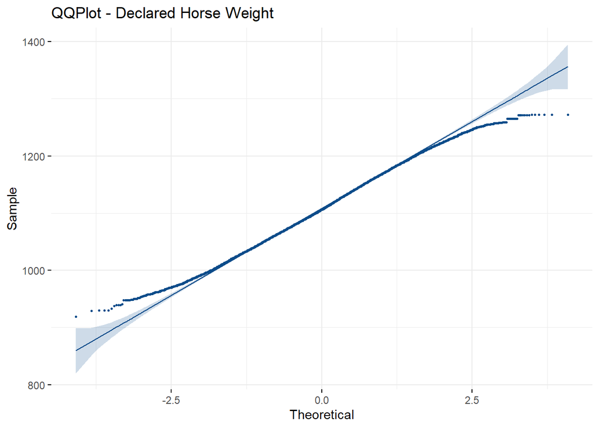

```r
dades <- sample(seq(1,nrow(dataset_clean), by =1), 5000)

ggqqplot(data=dataset_clean, x="declared_horse_weight", ggtheme = theme_minimal(), col = "#0c4c8a", conf.int = TRUE, size = 0.5, title = "QQPlot - Declared Horse Weight")
```

```r
shapiro.test(dataset_clean$declared_horse_weight[dades])
```

```
##
##  Shapiro-Wilk normality test
##
## data:  dataset_clean$declared_horse_weight[dades]
## W = 0.99679, p-value = 6.885e-09
```

#### 4. Win Odds

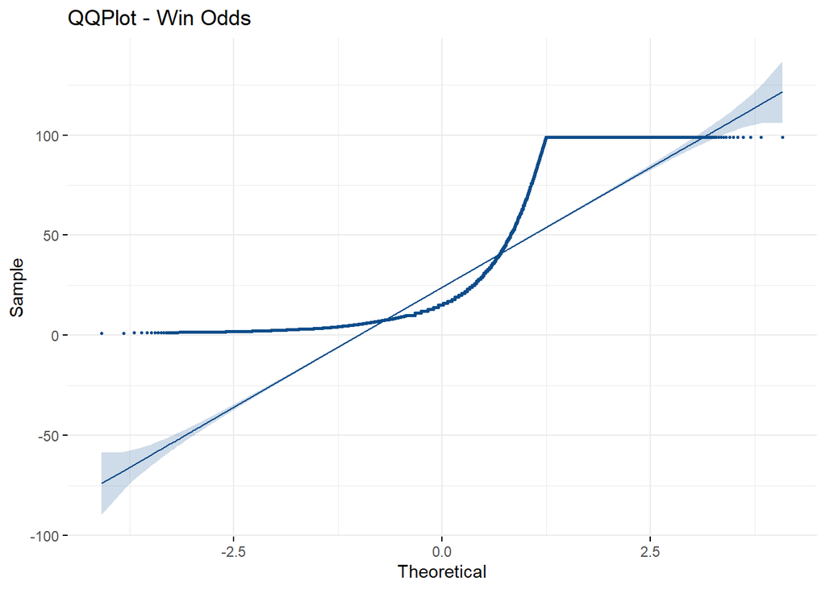

```r
dades <- sample(seq(1,nrow(dataset_clean), by =1), 5000)

ggqqplot(data=dataset_clean, x="win_odds", ggtheme = theme_minimal(), col = "#0c4c8a", conf.int = TRUE, size = 0.5, title = "QQPlot - Win Odds")
```

```r
shapiro.test(dataset_clean$win_odds[dades])
```

```
##
##  Shapiro-Wilk normality test
##
## data:  dataset_clean$win_odds[dades]
## W = 0.76028, p-value < 2.2e-16
```

Homogeneitat:

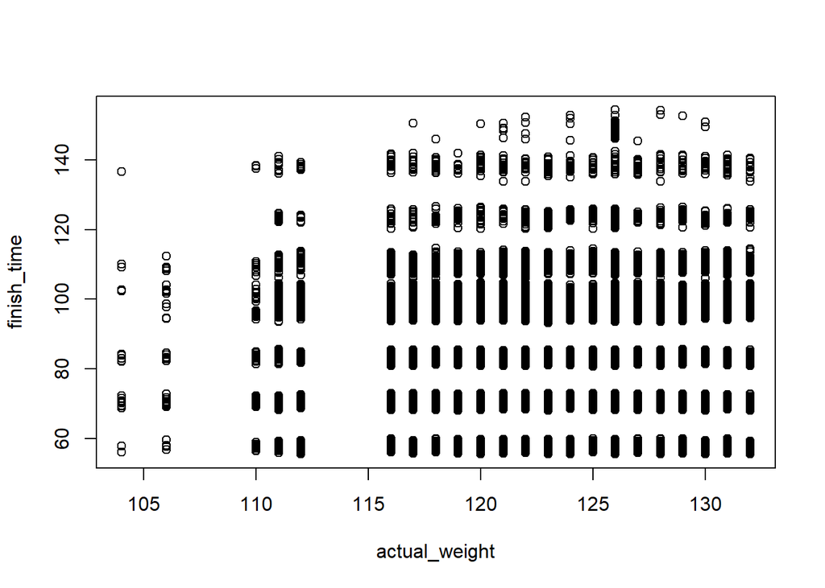

```r
#BT = bartlett.test(dataset_clean$finish_time ~ interaction(dataset_clean$actual_weight, dataset_clean$win_odds,dataset_clean$declared_horse_weight), data = dataset_clean )

plot(finish_time ~ actual_weight, data = dataset_clean)
```

```r
BT = bartlett.test(finish_time ~ actual_weight, data = dataset_clean )
print(BT)
```

```
##
##  Bartlett test of homogeneity of variances
##
## data:  finish_time by actual_weight
## Bartlett's K-squared = 180.7, df = 21, p-value < 2.2e-16
```

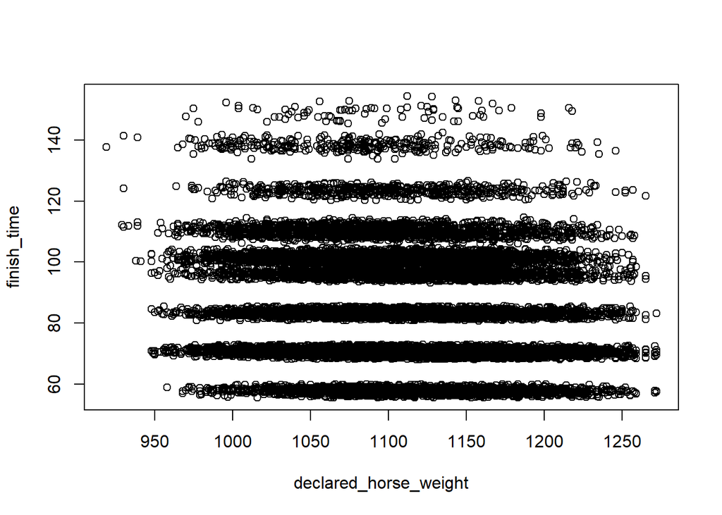

```r
plot(finish_time ~ declared_horse_weight, data = dataset_clean)
```

```r
#BT = bartlett.test(finish_time ~  declared_horse_weight, data = dataset_clean )
print(BT)
```

[output not shown]

[output not shown]

mirem la correlación entre els valors que són numerics, treiem en aquest cas la variable que es vol predir, que es el temps en que ha d’acabar un cavall, i fem la predicció per cada una de les diferents carreres, ja que no es comporten igual i com podem veure hi ha una correlació directe entre el temps de la cursa i la distancia.

```r
cor(x=dataset_clean$finish_time, y=as.numeric(dataset_clean$race_distance))
```

```
## [1] 0.9928419
```

mirem la resta de variables (treient la variable que tenim correlacionada amb el temps)

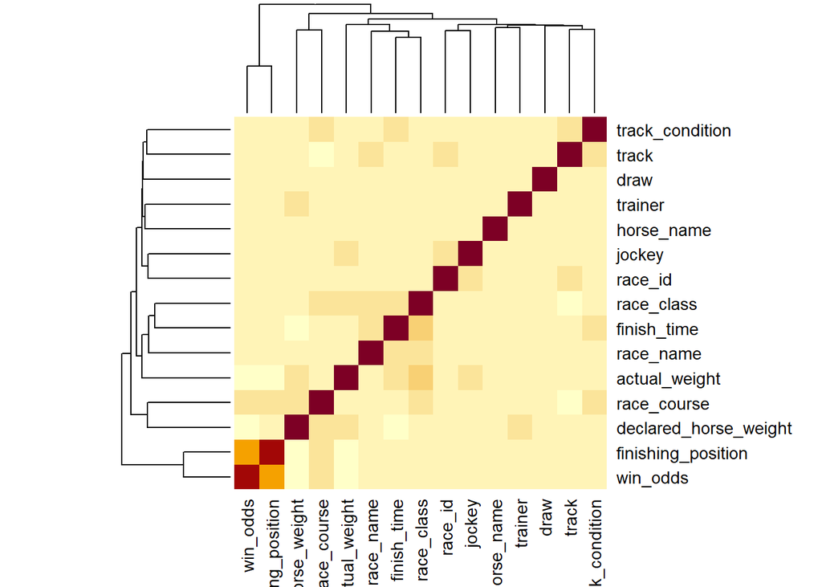

```r
#eliminar <- c("race_distance")
#dataset_clean <- dataset_clean[ , !(names(dataset_clean) %in% eliminar)]
num <- select_if(dataset_clean, is.numeric)
cat <- select_if(dataset_clean, is.character)
cat[] <- lapply(cat, as.factor)
for (name in colnames(cat)) {
  cat[name] <- unlist(lapply(cat[name], as.numeric))
}
dataset_numerical <- data.frame(num,cat)
cor <- rcorr(as.matrix(dataset_numerical), type = "pearson")
heatmap(cor$r)
```

en aquest cas veiem com la variable *win_odds* (la provabilitat de guanyar abans d’iniciar la cursa) té una correlació força alta amb la posició final de la cursa, cosa que es pot entendre per ser un bon cavall.

En aquest cas, la posició final de la cursa dependrà molt de la resta de cavalls que hi hagui i no del propi cavall, per tant, també es podria eliminar ja que no afecta a la predicció del resultat, sinó al resultat de cada cursa.